# DATA100 Introduction to Data Analytics

Lecture 2: The Whole Game - Day 1

Agassi Iu

Wilfrid Laurier University

2026-09-15

## The Whole Game

Imagine learning baseball by drilling practices into pitching, hitting, and fielding for three months, before ever seeing a new game.

**Warning**

This sounds exhausting. Nobody learns baseball that way.

Instead, you would play a simplified whole game first. - It is messy, imperfect, but real. - You’d get a feel for what the sport is before drilling into any of the skills.

## This course works the same way! :)

We are going to take a quick glimpse on what you are about to do in this course, over this week.

**Today**

Play the whole game once:

- An open question $\rightarrow$ some cool results

**Rest of semester**

Drill each piece:

- Cleaning, transformations, modelling, communication

By the end of the course, you’ll play the whole game again (*wink wink* this time completing the final project by yourself).

## Today’s Agenda

**Data Set**

Work with real Canadian financial wellness survey data.

**Why does this matter?**

- Financial stress affects health, relationships, and decision-making.
- Understanding *what predicts* financial comfort helps policymakers, employers, and individuals.

## What contributes to financial wellness?

**Checkpoint**

Take a minute to think about it: what factors do **you** think contribute to someone’s financial wellness?

- Is it someone’s current wealth?
- How much money are they making from their jobs?
- Is where you live a factor to how financially well are you?

*We’ll come back to your answers as we go through the questions.*

## The Data

**Data Overview**

Survey responses from Canadians regarding income, employment, financial habits, and workplace benefits.

- **Sample:** Canadians across all provinces
- **Scale:** 1,000 total respondents across two survey waves (in 2017 & 2022)
- **Scope:** Captures demographic variables alongside self-reported financial stress metrics (survey responses)

*Note: This data set originates from a real research project conducted in partnership with external industrial partners. To preserve confidentiality, the data has been anonymized and structured for teaching purposes.*

## 8 Survey Questions

1. What is your age?
2. Which province are you currently living in?
3. What is your annual income in dollars?
4. What percentage of your paycheck do you put into savings?
5. Are you currently overwhelmed by debt?
6. How manageable are you able to come up with $2,000 of emergency fund right now?
7. How manageable are you able to live if your paycheque arrives two weeks late?
8. What is the most important benefit that you seek from your job?

## Types of Variables

| # | Question | Variable Type |
| --- | --- | --- |
| 1 | Age | Continuous |
| 2 | Province | Categorical (Nominal) |
| 3 | Annual income (in CAD) | Continuous |
| 4 | Percentage of paycheck saved | Continuous |
| 5 | Overwhelmed by debt? | Categorical (Binary) |
| 6 | Manageability of $2,000 emergency fund | Likert (Ordinal) |
| 7 | Manageability of 2-week paycheque delay | Likert (Ordinal) |
| 8 | Most important job benefit | Categorical (Nominal) |

## Choosing How to Show Data

**Quick distinctions**

- **Continuous**: a numeric value that can (in theory) take any value in a range.
- **Categorical**: falls into one of several unordered groups (*nominal*) or has only two options (*binary*).
- **Likert**: an ordered scale (e.g., “very difficult” → “difficult” → … → “very manageable”)
  - categorical, but with a meaningful order.

**One idea to hold onto**

The **type of variable** decides the **type of plot**.

- One category at a time → **bar chart**
- One number at a time → **histogram**
- Two things at once → **scatterplot** (or boxplot, if one is a category)

## Glimpse of Data

```r
head(survey_2017)
```

```
# A tibble: 6 × 16
  respondent_id  year   age province      income savings_pct benefits_preference
  <chr>         <dbl> <dbl> <chr>          <dbl>       <dbl> <chr>
1 2017-0001      2017    31 Alberta        78300        21.6 More time off
2 2017-0002      2017    51 Newfoundland… 149500        21.8 Educational funding
3 2017-0003      2017    40 Manitoba       97700         8.2 Health benefits
4 2017-0004      2017    37 Ontario       102300        13.7 Higher wages
5 2017-0005      2017    39 British Colu… 118600         7.8 Health benefits
6 2017-0006      2017    43 Alberta        54400        16.9 Health benefits
# ℹ 9 more variables: paycheque_delay_difficulty <ord>, debt_overwhelmed <chr>,
#   emergency_fund_likelihood <ord>, financial_wellness_cluster <fct>,
#   paycheque_delay_score <dbl>, emergency_fund_score <dbl>, age_bucket <fct>,
#   income_bucket <fct>, province_bucket <chr>
```

**What’s a tibble?**

A tibble is just a table of rows and columns, like an Excel spreadsheet. It is how *R* stores and displays your data with just cleaner printing.

# Section 1: Demographics

## What does the sample look like?

**What do you notice?**

I am going to show you the demographic-response (i.e. age, income, and province) distributions from the 2017 survey results. Try and answer the following questions:

- Can you tell me if there are any obvious patterns?
- Do you like the plots that I created? What would you change?
- Based on those three plots, can you tell me anything about the financial wellness of the respondents?

## Income Distribution

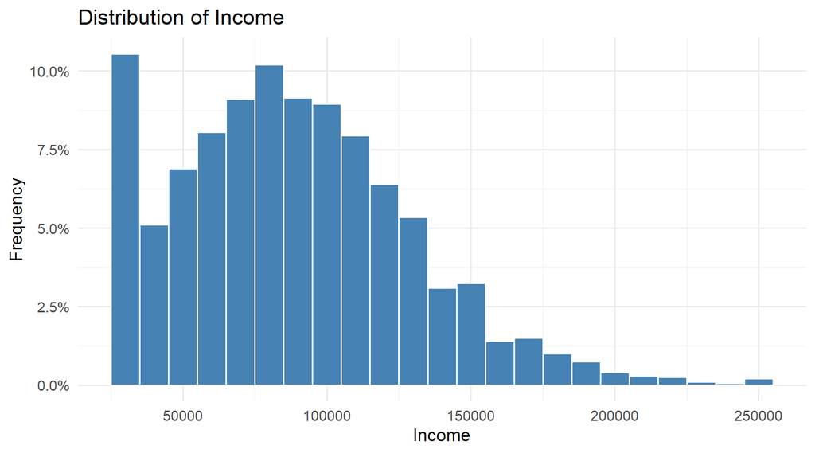

## Age Distribution

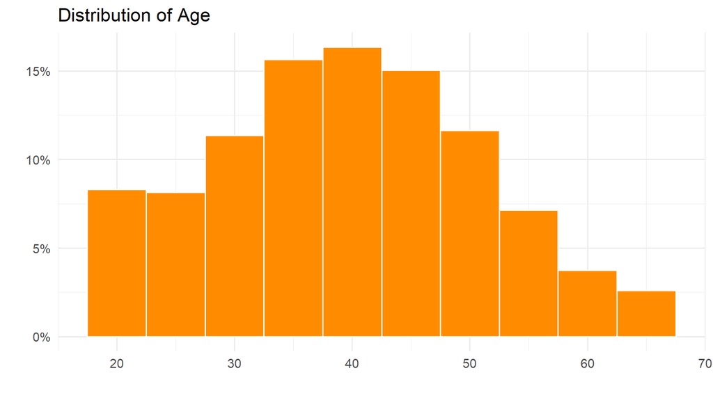

## Age Distribution (Correct Version)

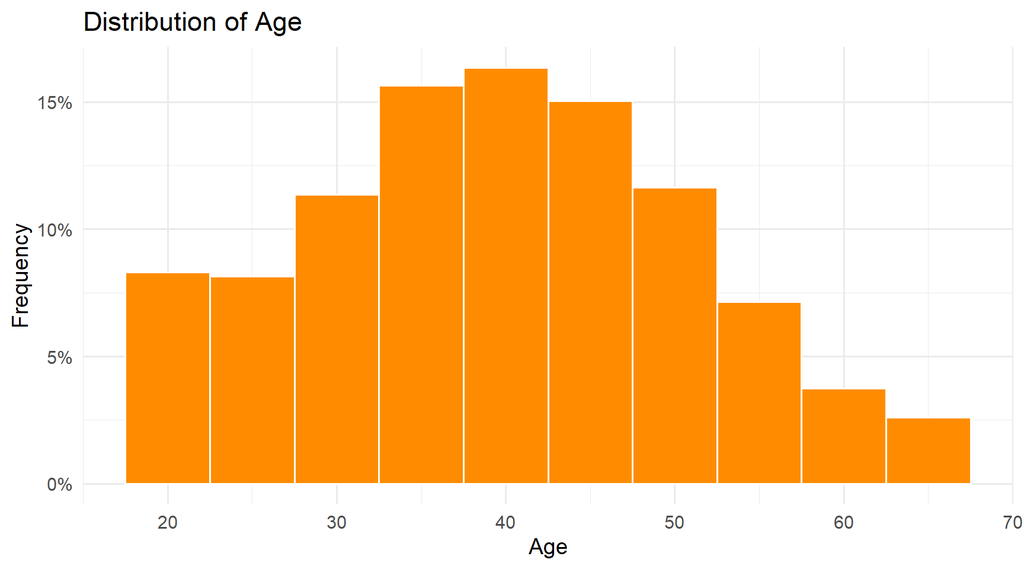

## Province Distribution

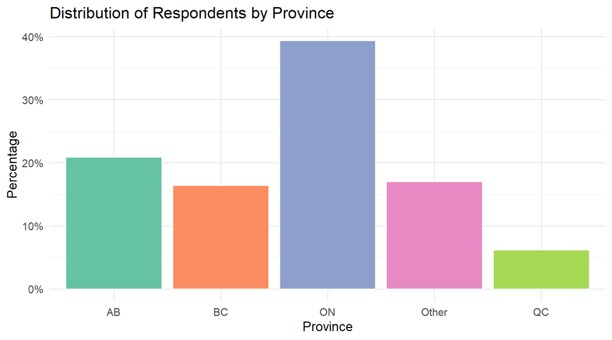

## For the rest of the lecture, keep thinking about these questions:

**Checkpoint**

- What kind of patterns do you recognize from the plots?
- How would you improve the readability of the plots?
- What can you tell me about the financial wellness from the survey results?

## Age vs Income

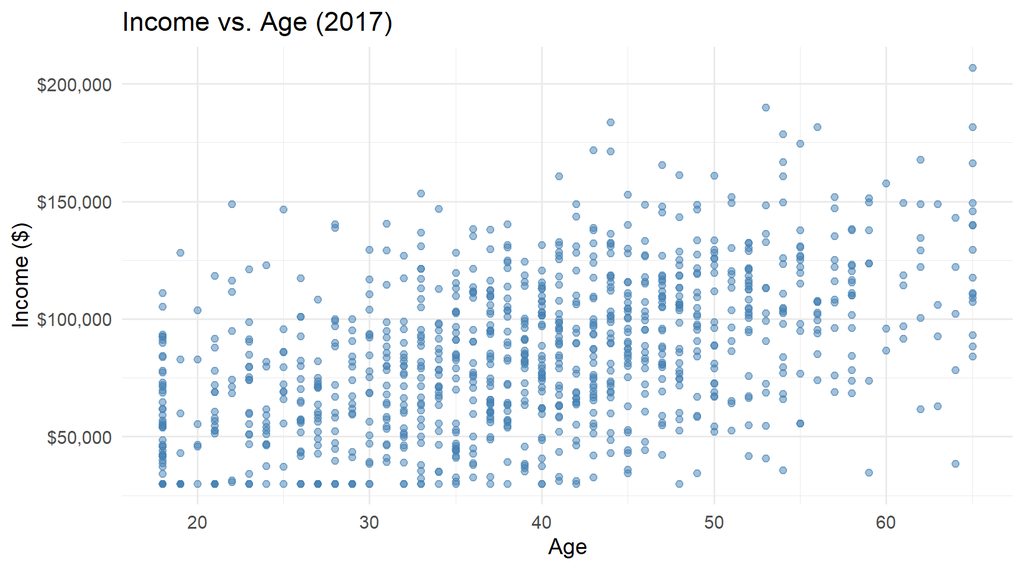

**Finding Patterns**

Let us try and fit something called a *Linear Model*. That is we let $y$ = income and $x$ = age, and we fit some function $y=f(x) = mx+b$ over this plot.

## Tell me about the patterns again?

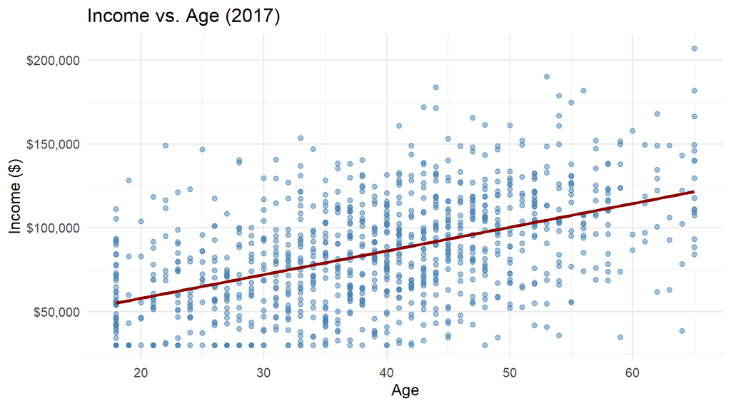

# Section 2: Financial Wellness Clusters

## How We Found These Groups/Clusters

- We didn’t set the rules manually: The patterns emerged directly from the survey data.
- *Unsupervised Learning:* We used algorithms to group respondents based on mathematical similarity across many variables at once.
  - Methods like *k-Nearest Neighbors (k-NN)* and *t-SNE* helped us reduce high-dimensional data into distinct clusters.
  - Don’t worry! The math behind clustering is **out of scope** of this course, just think of it as a tool that finds hidden patterns in complex data. If you are interested, you should take these courses in future.
    - *ST362* Regression Analysis , and
    - *ST494* Statistical Learning.

## Clustering Results

- Analyzed 100+ survey questions across 10+ years of longitudinal project data.
  - This is our *actual* work from the lab. I am only replicating a small subset of the data for this class.
- 3 groups proved to be the mathematical sweet spot (2 lost key details; 4 added unnecessary noise).
  1. Stressed
  2. Coping
  3. Comfortable
- Connects the data outputs directly to the client’s goal of understanding Canadian financial stress and security.

## Clustering Comparison

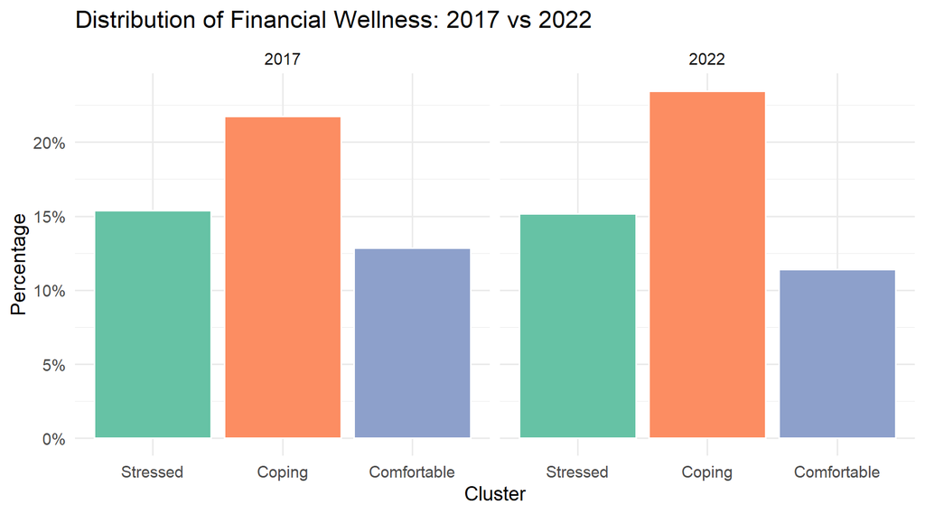

# Section 3: Financial and Behavioural Responses

## Savings Rate by Cluster (2017 vs 2022)

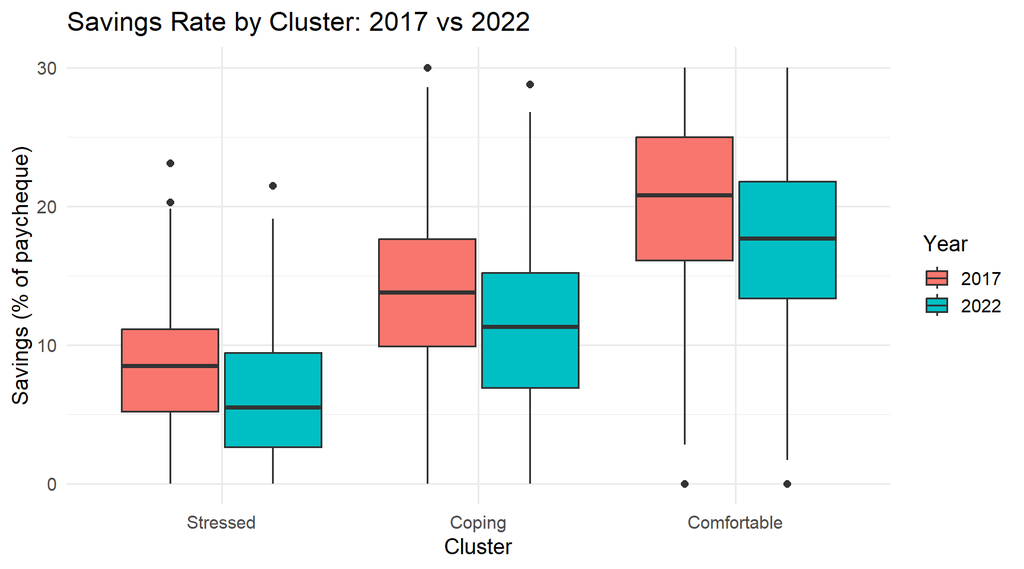

## Paycheque Delay Difficulty

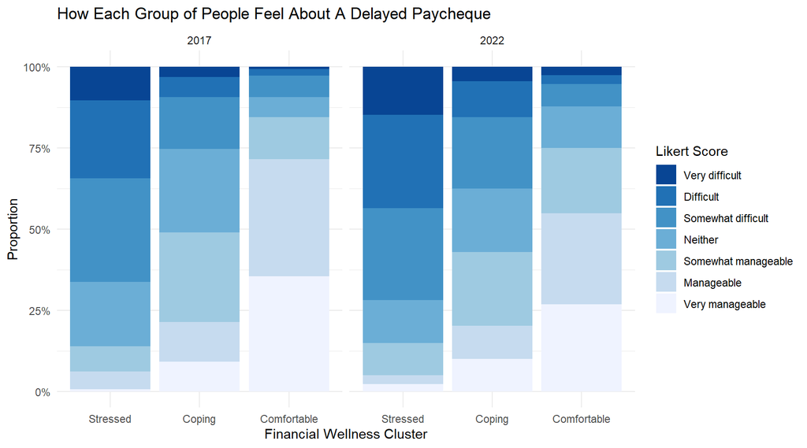

## Most Important Benefit

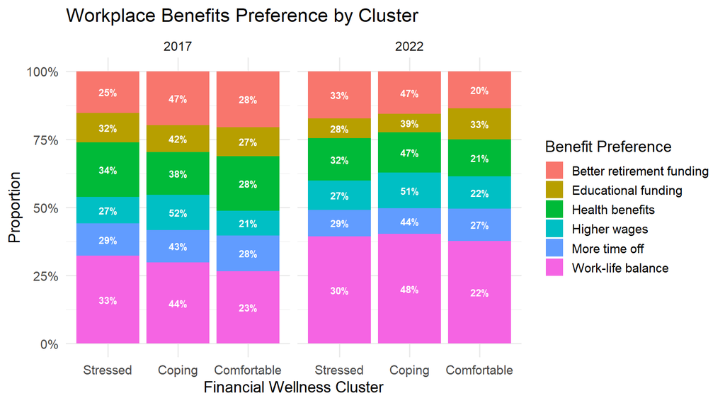

## Does Income Differ by Cluster?

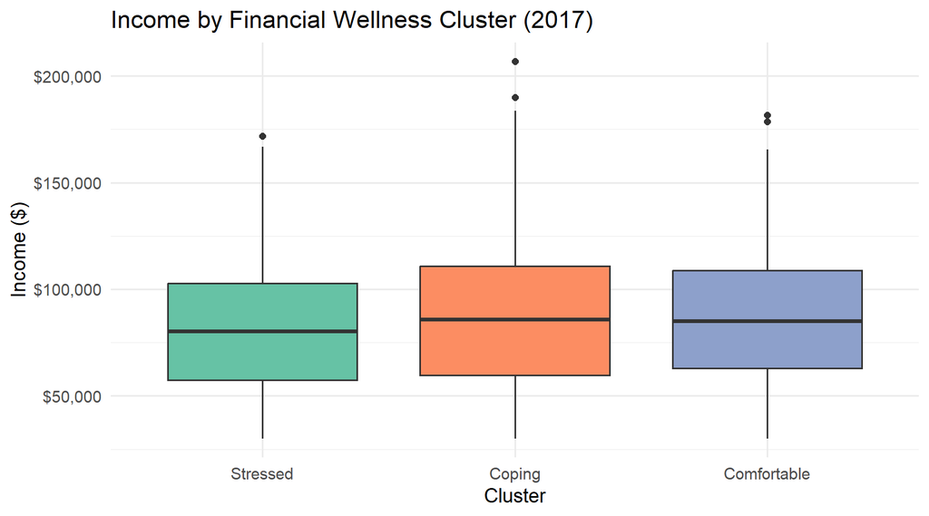

[figure not shown]

## What Happens When We Add a Third Variable?

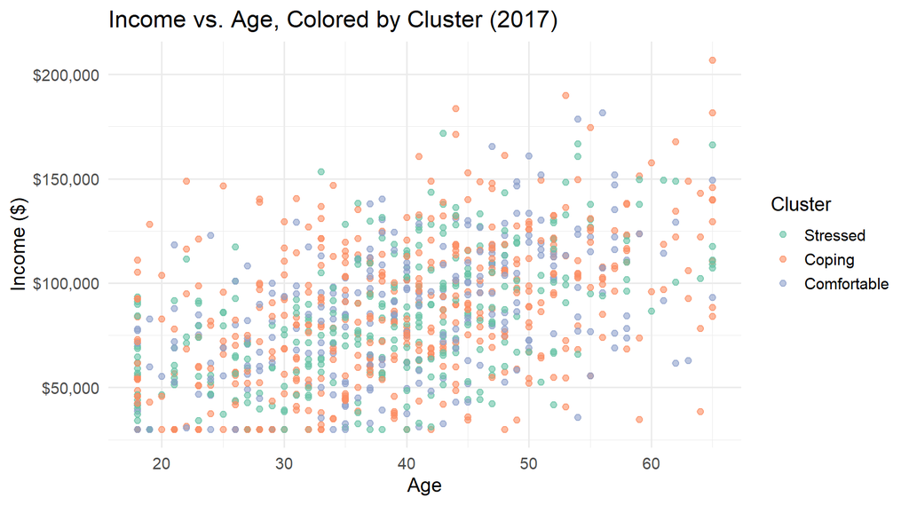

## Do you save more just because you make more?

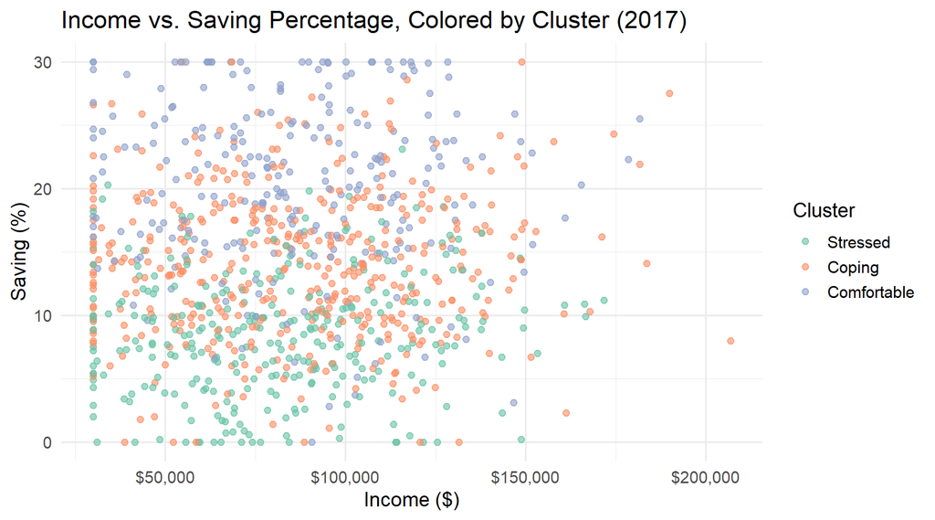

## Exercise

Try plotting yourself!

## Next Time:

How to clean the data so that we can work with it?